# **Part A: Convolutional Neural Network**

## __Previously__

1. All training for 128 and 31 images are done

```python
%pip install tensorflow_addons keras-tuner pandas matplotlib seaborn scikit-learn tqdm efficientnet numba
```

### Other Imports

```python
import numpy as np
import pandas as pd

import seaborn as sns

from matplotlib import pyplot as plt

from sklearn.metrics import classification_report, roc_auc_score, average_precision_score, confusion_matrix, cohen_kappa_score, matthews_corrcoef
from sklearn.metrics import classification_report,accuracy_score, confusion_matrix
from sklearn.decomposition import PCA
from sklearn.preprocessing import Normalizer
from sklearn.metrics import classification_report, accuracy_score

import os, time, math, datetime, warnings, pytz, glob
from IPython.display import display
from functools import reduce
import absl.logging
from tqdm import tqdm
import logging
from efficientnet.tfkeras import EfficientNetB3

absl.logging.set_verbosity(absl.logging.ERROR)
logging.getLogger('tensorflow').disabled = True
warnings.filterwarnings('ignore')
```

### Tensorflow Import

```python
import tensorflow as tf
from tensorflow.keras.utils import Sequence, to_categorical
from tensorflow import expand_dims
from tensorflow.keras import Sequential
from tensorflow.keras import layers as L
from tensorflow.keras import backend as K
from tensorflow.image import random_flip_left_right, random_crop, resize_with_crop_or_pad
from tensorflow.keras.utils import to_categorical, plot_model
from tensorflow.keras.models import Model, load_model
from tensorflow.keras.layers import (Dense, Input, InputLayer, Normalization, Flatten,BatchNormalization,
    Dropout,Conv2D, GlobalAveragePooling2D, MaxPooling2D, ReLU, Layer,Activation, Multiply, AveragePooling2D,
    Add, RandomRotation,Resizing, Rescaling, Reshape, Concatenate, concatenate, Lambda,LeakyReLU, ZeroPadding2D)
from tensorflow.keras.callbacks import EarlyStopping, ModelCheckpoint, LearningRateScheduler, ReduceLROnPlateau, TerminateOnNaN, TensorBoard, CSVLogger, Callback
from tensorflow.keras.backend import clear_session
from tensorflow.keras.optimizers import RMSprop, SGD, Adam, Adagrad, Adamax
from tensorflow.keras.regularizers import l2, L2
from tensorflow.keras.optimizers.schedules import *
from tensorflow.keras.metrics import FalseNegatives, categorical_crossentropy, sparse_categorical_crossentropy
from tensorflow.keras.losses import CategoricalCrossentropy
from tensorflow.keras.preprocessing.image import ImageDataGenerator
from tensorflow.image import *
from tensorflow_addons.optimizers import SWA
from tensorflow.keras import layers

from kerastuner.tuners import Hyperband
from kerastuner import RandomSearch
from kerastuner import HyperModel
# Setting a seaborn style
sns.set(style="whitegrid")
```

## __Import dataset__

Here is to import the dataset and proceed to do analysis on it

### 31 x 31 Images

```python
data_small = tf.keras.utils.image_dataset_from_directory('Dataset for CA1 part A/train'  ,
                                                   color_mode='rgb',
                                                   image_size=(31,31))
data_small
```

```
Found 9028 files belonging to 15 classes.
```

```
<BatchDataset element_spec=(TensorSpec(shape=(None, 31, 31, 3), dtype=tf.float32, name=None), TensorSpec(shape=(None,), dtype=tf.int32, name=None))>
```

```python
X_train_small = []
y_train_small = []

for images, labels in tqdm(data_small):
    images = tf.image.rgb_to_grayscale(images)
    X_train_small.append(images)
    y_train_small.append(labels)

X_train_small = np.concatenate(X_train_small, axis=0)
X_train_small = np.squeeze(X_train_small, axis=-1)
y_train_small = np.concatenate(y_train_small, axis=0)
```

```python
val_data_small = tf.keras.utils.image_dataset_from_directory('Dataset for CA1 part A/validation'  ,
                                                   color_mode='rgb',
                                                   image_size=(31,31))
val_data_small
```

```
Found 3000 files belonging to 15 classes.
```

```
<BatchDataset element_spec=(TensorSpec(shape=(None, 31, 31, 3), dtype=tf.float32, name=None), TensorSpec(shape=(None,), dtype=tf.int32, name=None))>
```

```python
X_val_small = []
y_val_small = []

for images, labels in tqdm(val_data_small):
    images = tf.image.rgb_to_grayscale(images)
    X_val_small.append(images)
    y_val_small.append(labels)

X_val_small = np.concatenate(X_val_small, axis=0)
X_val_small = np.squeeze(X_val_small, axis=-1)
y_val_small = np.concatenate(y_val_small, axis=0)
```

```python
test_data_small = tf.keras.utils.image_dataset_from_directory('Dataset for CA1 part A/test'  ,
                                                   color_mode='rgb',
                                                   image_size=(31,31))
test_data_small
```

```
Found 3000 files belonging to 15 classes.
```

```
<BatchDataset element_spec=(TensorSpec(shape=(None, 31, 31, 3), dtype=tf.float32, name=None), TensorSpec(shape=(None,), dtype=tf.int32, name=None))>
```

```python
X_test_small = []
y_test_small = []

for images, labels in tqdm(test_data_small):
    images = tf.image.rgb_to_grayscale(images)
    X_test_small.append(images)
    y_test_small.append(labels)

X_test_small = np.concatenate(X_test_small, axis=0)
X_test_small = np.squeeze(X_test_small, axis=-1)
y_test_small = np.concatenate(y_test_small, axis=0)
```

### 128 x 128

```python
data_big = tf.keras.utils.image_dataset_from_directory('Dataset for CA1 part A/train'  ,
                                                   color_mode='rgb',
                                                   image_size=(128,128))
data_big
```

```
Found 9028 files belonging to 15 classes.
```

```
<BatchDataset element_spec=(TensorSpec(shape=(None, 128, 128, 3), dtype=tf.float32, name=None), TensorSpec(shape=(None,), dtype=tf.int32, name=None))>
```

```python
X_train_big = []
y_train_big = []

for images, labels in tqdm(data_big):
    images = tf.image.rgb_to_grayscale(images)
    X_train_big.append(images)
    y_train_big.append(labels)

X_train_big = np.concatenate(X_train_big, axis=0)
X_train_big = np.squeeze(X_train_big, axis=-1)
y_train_big = np.concatenate(y_train_big, axis=0)
```

```python
val_data_big = tf.keras.utils.image_dataset_from_directory('Dataset for CA1 part A/validation'  ,
                                                   color_mode='rgb',
                                                   image_size=(128,128))
val_data_big
```

```
Found 3000 files belonging to 15 classes.
```

```
<BatchDataset element_spec=(TensorSpec(shape=(None, 128, 128, 3), dtype=tf.float32, name=None), TensorSpec(shape=(None,), dtype=tf.int32, name=None))>
```

```python
X_val_big = []
y_val_big = []

for images, labels in tqdm(val_data_big):
    images = tf.image.rgb_to_grayscale(images)
    X_val_big.append(images)
    y_val_big.append(labels)

X_val_big = np.concatenate(X_val_big, axis=0)
X_val_big = np.squeeze(X_val_big, axis=-1)
y_val_big = np.concatenate(y_val_big, axis=0)
```

```python
test_data_big = tf.keras.utils.image_dataset_from_directory('Dataset for CA1 part A/test'  ,
                                                   color_mode='rgb',
                                                   image_size=(128,128))
test_data_big
```

```
Found 3000 files belonging to 15 classes.
```

```
<BatchDataset element_spec=(TensorSpec(shape=(None, 128, 128, 3), dtype=tf.float32, name=None), TensorSpec(shape=(None,), dtype=tf.int32, name=None))>
```

```python
X_test_big = []
y_test_big = []

for images, labels in tqdm(test_data_big):
    images = tf.image.rgb_to_grayscale(images)
    X_test_big.append(images)
    y_test_big.append(labels)

X_test_big = np.concatenate(X_test_big, axis=0)
X_test_big = np.squeeze(X_test_big, axis=-1)
y_test_big = np.concatenate(y_test_big, axis=0)
```

```python
labels_dict = os.listdir('Dataset for CA1 part A/train')
labels_dict = {idx: label for idx, label in enumerate(labels_dict)}
print(labels_dict)
```

```
{0: 'Bean', 1: 'Bitter_Gourd', 2: 'Bottle_Gourd', 3: 'Brinjal', 4: 'Broccoli', 5: 'Cabbage', 6: 'Capsicum', 7: 'Carrot', 8: 'Cauliflower', 9: 'Cucumber', 10: 'Papaya', 11: 'Potato', 12: 'Pumpkin', 13: 'Radish', 14: 'Tomato'}
```

```python
y_train_small = to_categorical(y_train_small)
y_val_small = to_categorical(y_val_small)
```

```python
y_train_big = to_categorical(y_train_big)
y_val_big = to_categorical(y_val_big)
```

## __Required Functions__

Here is to define all the required functions

```python
def CNN2(name='Best_Model'):

    filters_list = [128, 128, 128]

    model = Sequential()

    # Add initial convolutional layers
    model.add(Conv2D(filters=filters_list[0], kernel_size=(3, 3), padding='same', input_shape=(31, 31, 1)))
    model.add(BatchNormalization())
    model.add(ReLU())

    model.add(Conv2D(filters=filters_list[1], kernel_size=(3, 3), padding='same'))
    model.add(BatchNormalization())
    model.add(ReLU())

    for filters in filters_list:
        model.add(Conv2D(filters=filters, kernel_size=(3, 3), padding='same'))
        model.add(BatchNormalization())
        model.add(ReLU())

    model.add(GlobalAveragePooling2D())
    model.add(Dense(256, activation='relu'))
    model.add(Dense(15, activation='softmax'))

    model.compile(optimizer='adam', loss='categorical_crossentropy', metrics=['accuracy'])
    model.summary()
    return model
```

```python
def evaluation_test(model, X_val, y_val, LABELS):
    final_predictions = model.predict(X_val)
    final_predictions_final = np.argmax(final_predictions, axis=1)
    y_test_final = np.argmax(y_val, axis=1) if y_val.ndim == 2 else y_val
    classification_results = classification_report(y_test_final, final_predictions_final, target_names=LABELS.values(), output_dict=True)

    print('Accuracy:', accuracy_score(y_test_final, final_predictions_final))
    result = pd.DataFrame(classification_results).transpose().sort_values('f1-score')
    return result
```

```python
def plot_classification_heatmap(df):
    heatmap_data = df.drop(['accuracy', 'macro avg', 'weighted avg']).iloc[:, :-1]
    plt.figure(figsize=(10, 8))
    sns.heatmap(heatmap_data, annot=True, fmt=".2f", cmap="Blues")
    plt.title("Classification Report Heatmap")
    plt.show()
```

```python
class Evaluator:
  def __init__(self, path=None, project_name="CNN_CA1"):
      # Initialize wandb
      self.project_name = project_name

      # Your existing initialization code
      if path:
          self.result = pd.read_csv(path, sep=';')
      else:
          cols = ['Model Name', 'Batch Size', "Train Loss", "Test Loss", "Train Acc", "Test Acc", "Remarks"]
          self.result = pd.DataFrame(columns=cols)

      self.callback = [
          TerminateOnNaN()
      ]
      # self.api = wandb.Api()

  def train_model(self, model, train, val, hyperparameters, callbacks):
    tf.keras.backend.clear_session()
    epochs = hyperparameters['max_epochs']
    batch_size = 64

    if val is None:
      X_train, y_train = train
      return model.fit(X_train, y_train, epochs=epochs, batch_size=64, validation_split = hyperparameters["val_split"], callbacks=callbacks).history
    else:
      return model.fit(train, validation_data = val, epochs = epochs, batch_size = batch_size , callbacks=callbacks).history

  def model_evaluate(self, train, val, model, hyperparameters, callbacks=None, plot_loss=True, remarks=""):
      tf.keras.backend.clear_session()
      # wandb.init(project=self.project_name)
      callbacks = (callbacks or [EarlyStopping(monitor='val_accuracy', patience=10, restore_best_weights=True), ReduceLROnPlateau(patience=5)]) + self.callback
      history = self.train_model(model, train, val, hyperparameters, callbacks)
      bestval_index = np.argmax(history['val_accuracy'])


      if plot_loss:
          try:
              fig = plot_model_history(history)
          except Exception as e:
              print(e, 'here')
              print("error creating loss curve")
              fig = None

      result = {
          "Model Name": model.name,
          "Epochs": len(history["loss"]),
          "Batch Size": hyperparameters["batch_size"],
          "Train Loss": history["loss"][bestval_index],
          "Test Loss": history["val_loss"][bestval_index],
          "Train Acc": history["accuracy"][bestval_index],
          "Test Acc": history["val_accuracy"][bestval_index]
      }
      # wandb.log({
      #     "Model Name": model.name,
      #     "Epochs": len(history["loss"]),
      #     "Batch Size": hyperparameters["batch_size"],
      #     "Train Loss": history["loss"][bestval_index],
      #     "Test Loss": history["val_loss"][bestval_index],
      #     "Train Acc": history["accuracy"][bestval_index],
      #     "Test Acc": history["val_accuracy"][bestval_index],
      # })

      # wandb.finish()
      return result, fig

  def _train_model(self, model, training_data, validation_data, hyperparameters, callbacks):
      tf.keras.backend.clear_session()
      epochs = hyperparameters["max_epochs"]
      batch_size = hyperparameters["batch_size"]

      if validation_data is None:
          X_train, y_train = training_data
          return model.fit(X_train, y_train, epochs=epochs, batch_size=batch_size, validation_split=hyperparameters["val_split"], callbacks=callbacks).history

      return model.fit(training_data, validation_data=validation_data, epochs=epochs, batch_size=batch_size, callbacks=callbacks).history
```

```python
def plot_model_history(model_history):
    history_df = pd.DataFrame(model_history)
    fig, axs = plt.subplots(1, 2, figsize=(14, 5))

    axs[0].plot(history_df['loss'], 'g--', label='Training Loss')
    axs[0].plot(history_df['val_loss'], 'b-', label='Validation Loss')
    axs[0].set_title('Training and Validation Loss')
    axs[0].set_xlabel('Epochs')
    axs[0].set_ylabel('Loss')
    axs[0].legend()
    axs[0].grid(True)

    if 'accuracy' in history_df and 'val_accuracy' in history_df:
        axs[1].plot(history_df['accuracy'], 'g--', label='Training Accuracy')
        axs[1].plot(history_df['val_accuracy'], 'b-', label='Validation Accuracy')
        axs[1].set_title('Training and Validation Accuracy')
        axs[1].set_xlabel('Epochs')
        axs[1].set_ylabel('Accuracy')
        axs[1].legend()
        axs[1].grid(True)

    plt.tight_layout()
    plt.close(fig)

    def show():
        display(fig)

    return show
```

```python
def preprocess_data(image, label):
  image = tf.expand_dims(image, -1)
  return image, label

def sample_beta_distribution(size, concentration_0=300, concentration_1=0.1):
  gamma_1_sample = tf.random.gamma(shape=[size], alpha=concentration_1)
  gamma_2_sample = tf.random.gamma(shape=[size], alpha=concentration_0)
  return gamma_1_sample / (gamma_1_sample + gamma_2_sample)


@tf.function
def get_box(lambda_value):
  cut_rat = tf.math.sqrt(1.0 - lambda_value)
  image_wh = (31,31,1)[0]
  cut_wh = image_wh * cut_rat  # rw
  cut_wh = tf.cast(cut_wh, tf.int32)

  cut_x = tf.random.uniform((1,), minval=0, maxval=image_wh, dtype=tf.int32)  # rx
  cut_y = tf.random.uniform((1,), minval=0, maxval=image_wh, dtype=tf.int32)  # ry

  boundaryx1 = tf.clip_by_value(cut_x[0] - cut_wh // 2, 0, image_wh)
  boundaryy1 = tf.clip_by_value(cut_y[0] - cut_wh // 2, 0, image_wh)
  bbx2 = tf.clip_by_value(cut_x[0] + cut_wh // 2, 0, image_wh)
  bby2 = tf.clip_by_value(cut_y[0] + cut_wh // 2, 0, image_wh)

  target_h = bby2 - boundaryy1
  if target_h == 0:
      target_h += 1

  target_w = bbx2 - boundaryx1
  if target_w == 0:
      target_w += 1

  return boundaryx1, boundaryy1, target_h, target_w


@tf.function
def cutmix(train_ds_one, train_ds_two):
  (image1, label1), (image2, label2) = train_ds_one, train_ds_two
  image_size = (31,31,1)[0]
  alpha = [1]
  beta = [1]
  lambda_value = sample_beta_distribution(1, alpha, beta)
  lambda_value = lambda_value[0][0]
  boundaryx1, boundaryy1, target_h, target_w = get_box(lambda_value)
  crop2 = tf.image.crop_to_bounding_box(
      image2, boundaryy1, boundaryx1, target_h, target_w
  )
  image2 = tf.image.pad_to_bounding_box(
      crop2, boundaryy1, boundaryx1, image_size, image_size
  )
  crop1 = tf.image.crop_to_bounding_box(
      image1, boundaryy1, boundaryx1, target_h, target_w
  )
  img1 = tf.image.pad_to_bounding_box(
      crop1, boundaryy1, boundaryx1, image_size, image_size
  )

  image1 = image1 - img1
  image = image1 + image2
  lambda_value = 1 - (target_w * target_h) / (image_size * image_size)
  lambda_value = tf.cast(lambda_value, tf.float32)
  label = lambda_value * label1 + (1 - lambda_value) * label2
  return image, label


@tf.function
def get_box2(lambda_value):
  cut_rat = tf.math.sqrt(1.0 - lambda_value)
  image_wh = (31,31,1)[0]
  cut_wh = image_wh * cut_rat  # rw
  cut_wh = tf.cast(cut_wh, tf.int32)

  cut_x = tf.random.uniform((1,), minval=0, maxval=image_wh, dtype=tf.int32)  # rx
  cut_y = tf.random.uniform((1,), minval=0, maxval=image_wh, dtype=tf.int32)  # ry

  boundaryx1 = tf.clip_by_value(cut_x[0] - cut_wh // 2, 0, image_wh)
  boundaryy1 = tf.clip_by_value(cut_y[0] - cut_wh // 2, 0, image_wh)
  bbx2 = tf.clip_by_value(cut_x[0] + cut_wh // 2, 0, image_wh)
  bby2 = tf.clip_by_value(cut_y[0] + cut_wh // 2, 0, image_wh)

  target_h = bby2 - boundaryy1
  if target_h == 0:
      target_h += 1

  target_w = bbx2 - boundaryx1
  if target_w == 0:
      target_w += 1

  return boundaryx1, boundaryy1, target_h, target_w
@tf.function
def cutmix2(train_ds_one, train_ds_two):
  (image1, label1), (image2, label2) = train_ds_one, train_ds_two
  image_size = (128,128,1)[0]
  alpha = [1]
  beta = [1]
  lambda_value = sample_beta_distribution(1, alpha, beta)
  lambda_value = lambda_value[0][0]
  boundaryx1, boundaryy1, target_h, target_w = get_box2(lambda_value)
  crop2 = tf.image.crop_to_bounding_box(
      image2, boundaryy1, boundaryx1, target_h, target_w
  )
  image2 = tf.image.pad_to_bounding_box(
      crop2, boundaryy1, boundaryx1, image_size, image_size
  )
  crop1 = tf.image.crop_to_bounding_box(
      image1, boundaryy1, boundaryx1, target_h, target_w
  )
  img1 = tf.image.pad_to_bounding_box(
      crop1, boundaryy1, boundaryx1, image_size, image_size
  )

  image1 = image1 - img1
  image = image1 + image2
  lambda_value = 1 - (target_w * target_h) / (image_size * image_size)
  lambda_value = tf.cast(lambda_value, tf.float32)
  label = lambda_value * label1 + (1 - lambda_value) * label2
  return image, label
```

```python
train_ds_one = tf.data.Dataset.from_tensor_slices((X_train_small, y_train_small)).shuffle(2048).map(preprocess_data, num_parallel_calls=tf.data.AUTOTUNE)
train_ds_two = tf.data.Dataset.from_tensor_slices((X_train_small, y_train_small)).shuffle(2048).map(preprocess_data, num_parallel_calls=tf.data.AUTOTUNE)

val_ds_cutmix = tf.data.Dataset.from_tensor_slices((X_val_small, y_val_small))
val_ds_cutmix = val_ds_cutmix.map(preprocess_data, num_parallel_calls=tf.data.AUTOTUNE).batch(128).prefetch(tf.data.AUTOTUNE)

train_ds_cutmix = tf.data.Dataset.zip((train_ds_one, train_ds_two))
train_ds_cutmix = (
    train_ds_cutmix.shuffle(1024)
    .map(cutmix, num_parallel_calls=tf.data.AUTOTUNE)
    .batch(128)
    .prefetch(tf.data.AUTOTUNE)
)
train_ds_cutmix
```

```
<PrefetchDataset element_spec=(TensorSpec(shape=(None, 31, 31, 1), dtype=tf.float32, name=None), TensorSpec(shape=(None, 15), dtype=tf.float32, name=None))>
```

## __General Comparison__

Here we compare over the results of each size

```python
overall_31 = pd.read_csv('BaselineModel (31x31).csv')
overall_31
```

|  | Unnamed: 0 | Model Name | Epochs | Batch Size | Train Loss | Test Loss | Train Acc | Test Acc | Kappa | Comments |
| --- | --- | --- | --- | --- | --- | --- | --- | --- | --- | --- |
| 0 | 5 | EfficientNet (Transfer Learning) | 35 | 128 | 0.000518 | 0.016012 | 0.998782 | 0.969000 | 0.969286 | NaN |
| 1 | 2 | CNN_Baseline2 | 44 | 128 | 0.025112 | 0.111673 | 0.998006 | 0.968000 | 0.968571 | NaN |
| 2 | 1 | CNN_Baseline | 52 | 128 | 0.074410 | 0.261325 | 0.976961 | 0.927333 | 0.924643 | NaN |
| 3 | 3 | VGGNet_Baseline | 52 | 128 | 0.164630 | 0.273673 | 0.999668 | 0.968333 | 0.962857 | NaN |
| 4 | 0 | Baseline_Dense_Model | 42 | 128 | 0.914943 | 1.486889 | 0.715884 | 0.554000 | 0.527857 | NaN |
| 5 | 4 | Resnet50 | 46 | 128 | 3.042697 | 3.611549 | 0.998892 | 0.875667 | 0.866071 | NaN |

```python
overall_31_2 = pd.read_csv('ModelImprovement(31x31).csv')
overall_31_2
```

|  | Unnamed: 0 | Model Name | Epochs | Batch Size | Train Loss | Test Loss | Train Acc | Test Acc | Kappa | Comments |
| --- | --- | --- | --- | --- | --- | --- | --- | --- | --- | --- |
| 0 | 0 | CNN basic one | 55 | 128 | 0.265317 | 0.782885 | 0.917590 | 0.759000 | 0.758214 | NaN |
| 1 | 1 | CNN2 basic one | 62 | 128 | 0.055647 | 0.220854 | 0.995791 | 0.932333 | 0.935714 | NaN |
| 2 | 2 | VGG_Baseline basic one | 60 | 128 | 0.294381 | 1.146233 | 0.986819 | 0.790000 | 0.768929 | NaN |
| 3 | 3 | CNN basic two | 42 | 128 | 0.306000 | 0.914004 | 0.904519 | 0.746667 | 0.732857 | NaN |
| 4 | 4 | CNN2 basic two | 50 | 128 | 0.053326 | 0.204810 | 0.994572 | 0.934333 | 0.936429 | NaN |
| 5 | 5 | VGG_Baseline basic two | 52 | 128 | 0.505366 | 0.985963 | 0.919251 | 0.787333 | 0.776071 | NaN |
| 6 | 6 | CNN cutmix | 61 | 128 | 1.301283 | 0.363114 | 0.761630 | 0.918667 | 0.918571 | NaN |
| 7 | 7 | CNN2 cutmix | 45 | 128 | 0.987957 | 0.187654 | 0.864754 | 0.970000 | 0.970000 | NaN |
| 8 | 8 | VGG_Baseline cutmix | 100 | 128 | 1.078563 | 0.375441 | 0.839721 | 0.965667 | 0.965357 | NaN |
| 9 | 9 | CNN cutout | 77 | 128 | 0.223899 | 0.374999 | 0.929331 | 0.891333 | 0.930714 | NaN |
| 10 | 10 | CNN2 cutout | 49 | 128 | 0.112434 | 0.198032 | 0.972198 | 0.942000 | 0.963214 | NaN |
| 11 | 11 | VGG_Baseline cutout | 100 | 128 | 0.302578 | 0.476259 | 0.982942 | 0.935333 | 0.958571 | NaN |
| 12 | 12 | CNN_Reg | 42 | 128 | 1.055568 | 1.137099 | 0.977736 | 0.937667 | 0.936071 | NaN |
| 13 | 13 | CNN2_Reg | 96 | 128 | 1.282831 | 0.384980 | 0.832743 | 0.960667 | 0.955357 | NaN |
| 14 | 14 | CNN1_SpecialLR | 100 | 128 | 1.015607 | 0.218915 | 0.833518 | 0.956667 | 0.955357 | NaN |

```python
overall_31 =  pd.concat([overall_31, overall_31_2], ignore_index=True)
overall_31
```

|  | Unnamed: 0 | Model Name | Epochs | Batch Size | Train Loss | Test Loss | Train Acc | Test Acc | Kappa | Comments |
| --- | --- | --- | --- | --- | --- | --- | --- | --- | --- | --- |
| 0 | 5 | EfficientNet (Transfer Learning) | 35 | 128 | 0.000518 | 0.016012 | 0.998782 | 0.969000 | 0.969286 | NaN |
| 1 | 2 | CNN_Baseline2 | 44 | 128 | 0.025112 | 0.111673 | 0.998006 | 0.968000 | 0.968571 | NaN |
| 2 | 1 | CNN_Baseline | 52 | 128 | 0.074410 | 0.261325 | 0.976961 | 0.927333 | 0.924643 | NaN |
| 3 | 3 | VGGNet_Baseline | 52 | 128 | 0.164630 | 0.273673 | 0.999668 | 0.968333 | 0.962857 | NaN |
| 4 | 0 | Baseline_Dense_Model | 42 | 128 | 0.914943 | 1.486889 | 0.715884 | 0.554000 | 0.527857 | NaN |
| 5 | 4 | Resnet50 | 46 | 128 | 3.042697 | 3.611549 | 0.998892 | 0.875667 | 0.866071 | NaN |
| 6 | 0 | CNN basic one | 55 | 128 | 0.265317 | 0.782885 | 0.917590 | 0.759000 | 0.758214 | NaN |
| 7 | 1 | CNN2 basic one | 62 | 128 | 0.055647 | 0.220854 | 0.995791 | 0.932333 | 0.935714 | NaN |
| 8 | 2 | VGG_Baseline basic one | 60 | 128 | 0.294381 | 1.146233 | 0.986819 | 0.790000 | 0.768929 | NaN |
| 9 | 3 | CNN basic two | 42 | 128 | 0.306000 | 0.914004 | 0.904519 | 0.746667 | 0.732857 | NaN |
| 10 | 4 | CNN2 basic two | 50 | 128 | 0.053326 | 0.204810 | 0.994572 | 0.934333 | 0.936429 | NaN |
| 11 | 5 | VGG_Baseline basic two | 52 | 128 | 0.505366 | 0.985963 | 0.919251 | 0.787333 | 0.776071 | NaN |
| 12 | 6 | CNN cutmix | 61 | 128 | 1.301283 | 0.363114 | 0.761630 | 0.918667 | 0.918571 | NaN |
| 13 | 7 | CNN2 cutmix | 45 | 128 | 0.987957 | 0.187654 | 0.864754 | 0.970000 | 0.970000 | NaN |
| 14 | 8 | VGG_Baseline cutmix | 100 | 128 | 1.078563 | 0.375441 | 0.839721 | 0.965667 | 0.965357 | NaN |
| 15 | 9 | CNN cutout | 77 | 128 | 0.223899 | 0.374999 | 0.929331 | 0.891333 | 0.930714 | NaN |
| 16 | 10 | CNN2 cutout | 49 | 128 | 0.112434 | 0.198032 | 0.972198 | 0.942000 | 0.963214 | NaN |
| 17 | 11 | VGG_Baseline cutout | 100 | 128 | 0.302578 | 0.476259 | 0.982942 | 0.935333 | 0.958571 | NaN |
| 18 | 12 | CNN_Reg | 42 | 128 | 1.055568 | 1.137099 | 0.977736 | 0.937667 | 0.936071 | NaN |
| 19 | 13 | CNN2_Reg | 96 | 128 | 1.282831 | 0.384980 | 0.832743 | 0.960667 | 0.955357 | NaN |
| 20 | 14 | CNN1_SpecialLR | 100 | 128 | 1.015607 | 0.218915 | 0.833518 | 0.956667 | 0.955357 | NaN |

```python
overall_128 = pd.read_csv('BaselineModel (128x128).csv')
overall_128
```

|  | Unnamed: 0 | Model Name | Epochs | Batch Size | Train Loss | Test Loss | Train Acc | Test Acc | Kappa | Comments |
| --- | --- | --- | --- | --- | --- | --- | --- | --- | --- | --- |
| 0 | 6 | EfficientNet (Transfer Learning) | 23 | 16 | 0.000292 | 0.000503 | 0.999557 | 0.999000 | 0.997500 | NaN |
| 1 | 2 | CNN_Baseline2 | 38 | 16 | 0.068800 | 0.097689 | 0.989699 | 0.980667 | 0.977500 | NaN |
| 2 | 1 | CNN_Baseline | 37 | 16 | 0.013904 | 0.193325 | 0.997785 | 0.942000 | 0.954286 | NaN |
| 3 | 3 | VGGNet_Baseline | 71 | 16 | 0.157832 | 0.213377 | 0.996012 | 0.980333 | 0.982857 | NaN |
| 4 | 4 | AlexNet_Baseline | 37 | 16 | 0.003087 | 0.254574 | 0.999114 | 0.946333 | 0.944643 | NaN |
| 5 | 0 | Baseline_Dense_Model | 58 | 16 | 0.910382 | 1.433305 | 0.707576 | 0.580667 | 0.547143 | NaN |
| 6 | 5 | Resnet50 | 68 | 16 | 1.447120 | 1.647934 | 0.999778 | 0.955000 | 0.954643 | NaN |

```python
overall_128_2 = pd.read_csv('ModelImprovement(128x128).csv')
overall_128_2
```

|  | Unnamed: 0 | Model Name | Epochs | Batch Size | Train Loss | Test Loss | Train Acc | Test Acc | Kappa | Comments |
| --- | --- | --- | --- | --- | --- | --- | --- | --- | --- | --- |
| 0 | 0 | CNN basic one | 38 | 128 | 0.017855 | 0.623409 | 0.996677 | 0.840000 | 0.839286 | NaN |
| 1 | 1 | CNN2 basic one | 53 | 128 | 0.015596 | 0.062343 | 0.999668 | 0.982667 | 0.985000 | NaN |
| 2 | 2 | VGG_Baseline basic one | 63 | 128 | 0.169651 | 0.240200 | 0.996788 | 0.974000 | 0.972500 | NaN |
| 3 | 3 | CNN basic two | 24 | 128 | 0.228279 | 0.786181 | 0.941294 | 0.758333 | 0.745714 | NaN |
| 4 | 4 | CNN2 basic two | 77 | 128 | 0.038791 | 0.089882 | 0.997009 | 0.979000 | 0.979286 | NaN |
| 5 | 5 | VGG_Baseline basic two | 98 | 128 | 0.144072 | 0.220837 | 0.999778 | 0.976333 | 0.974643 | NaN |
| 6 | 6 | CNN cutmix | 42 | 128 | 0.164451 | 0.178881 | 0.998892 | 0.945667 | 0.951071 | NaN |
| 7 | 7 | CNN2 cutmix | 52 | 128 | 0.157783 | 0.055629 | 0.999335 | 0.992333 | 0.990714 | NaN |
| 8 | 8 | VGG_Baseline cutmix | 71 | 128 | 0.238155 | 0.141491 | 0.999889 | 0.994333 | 0.991429 | NaN |
| 9 | 9 | CNN cutout | 44 | 128 | 0.009736 | 0.181197 | 0.997674 | 0.951667 | 0.956429 | NaN |
| 10 | 10 | CNN2 cutout | 45 | 128 | 0.042143 | 0.069994 | 0.994019 | 0.984000 | 0.981786 | NaN |
| 11 | 11 | VGG_Baseline cutout | 80 | 128 | 0.129479 | 0.174903 | 0.999225 | 0.986333 | 0.983214 | NaN |
| 12 | 12 | CNN_Reg | 44 | 128 | 0.881994 | 0.921476 | 0.995126 | 0.964667 | 0.964643 | NaN |
| 13 | 13 | CNN2_Reg | 78 | 128 | 0.307886 | 0.334669 | 0.985711 | 0.970333 | 0.967143 | NaN |

```python
overall_128 =  pd.concat([overall_128, overall_128_2], ignore_index=True)
overall_128
```

|  | Unnamed: 0 | Model Name | Epochs | Batch Size | Train Loss | Test Loss | Train Acc | Test Acc | Kappa | Comments |
| --- | --- | --- | --- | --- | --- | --- | --- | --- | --- | --- |
| 0 | 6 | EfficientNet (Transfer Learning) | 23 | 16 | 0.000292 | 0.000503 | 0.999557 | 0.999000 | 0.997500 | NaN |
| 1 | 2 | CNN_Baseline2 | 38 | 16 | 0.068800 | 0.097689 | 0.989699 | 0.980667 | 0.977500 | NaN |
| 2 | 1 | CNN_Baseline | 37 | 16 | 0.013904 | 0.193325 | 0.997785 | 0.942000 | 0.954286 | NaN |
| 3 | 3 | VGGNet_Baseline | 71 | 16 | 0.157832 | 0.213377 | 0.996012 | 0.980333 | 0.982857 | NaN |
| 4 | 4 | AlexNet_Baseline | 37 | 16 | 0.003087 | 0.254574 | 0.999114 | 0.946333 | 0.944643 | NaN |
| 5 | 0 | Baseline_Dense_Model | 58 | 16 | 0.910382 | 1.433305 | 0.707576 | 0.580667 | 0.547143 | NaN |
| 6 | 5 | Resnet50 | 68 | 16 | 1.447120 | 1.647934 | 0.999778 | 0.955000 | 0.954643 | NaN |
| 7 | 0 | CNN basic one | 38 | 128 | 0.017855 | 0.623409 | 0.996677 | 0.840000 | 0.839286 | NaN |
| 8 | 1 | CNN2 basic one | 53 | 128 | 0.015596 | 0.062343 | 0.999668 | 0.982667 | 0.985000 | NaN |
| 9 | 2 | VGG_Baseline basic one | 63 | 128 | 0.169651 | 0.240200 | 0.996788 | 0.974000 | 0.972500 | NaN |
| 10 | 3 | CNN basic two | 24 | 128 | 0.228279 | 0.786181 | 0.941294 | 0.758333 | 0.745714 | NaN |
| 11 | 4 | CNN2 basic two | 77 | 128 | 0.038791 | 0.089882 | 0.997009 | 0.979000 | 0.979286 | NaN |
| 12 | 5 | VGG_Baseline basic two | 98 | 128 | 0.144072 | 0.220837 | 0.999778 | 0.976333 | 0.974643 | NaN |
| 13 | 6 | CNN cutmix | 42 | 128 | 0.164451 | 0.178881 | 0.998892 | 0.945667 | 0.951071 | NaN |
| 14 | 7 | CNN2 cutmix | 52 | 128 | 0.157783 | 0.055629 | 0.999335 | 0.992333 | 0.990714 | NaN |
| 15 | 8 | VGG_Baseline cutmix | 71 | 128 | 0.238155 | 0.141491 | 0.999889 | 0.994333 | 0.991429 | NaN |
| 16 | 9 | CNN cutout | 44 | 128 | 0.009736 | 0.181197 | 0.997674 | 0.951667 | 0.956429 | NaN |
| 17 | 10 | CNN2 cutout | 45 | 128 | 0.042143 | 0.069994 | 0.994019 | 0.984000 | 0.981786 | NaN |
| 18 | 11 | VGG_Baseline cutout | 80 | 128 | 0.129479 | 0.174903 | 0.999225 | 0.986333 | 0.983214 | NaN |
| 19 | 12 | CNN_Reg | 44 | 128 | 0.881994 | 0.921476 | 0.995126 | 0.964667 | 0.964643 | NaN |
| 20 | 13 | CNN2_Reg | 78 | 128 | 0.307886 | 0.334669 | 0.985711 | 0.970333 | 0.967143 | NaN |

*Things Observed*

- From above, we can see that 128 images generally fare better than 31

## __Final 31 x 31 Model__

Here is to define all the required functions

### CNN 2 with Cutmix

```python
final_model = CNN2()
```

```
Model: "sequential_6"
_________________________________________________________________
 Layer (type)                Output Shape              Param #
=================================================================
 conv2d_34 (Conv2D)          (None, 31, 31, 128)       1280

 batch_normalization_34 (Bat  (None, 31, 31, 128)      512
 chNormalization)

 re_lu_34 (ReLU)             (None, 31, 31, 128)       0

 conv2d_35 (Conv2D)          (None, 31, 31, 128)       147584

 batch_normalization_35 (Bat  (None, 31, 31, 128)      512
 chNormalization)

 re_lu_35 (ReLU)             (None, 31, 31, 128)       0

 conv2d_36 (Conv2D)          (None, 31, 31, 128)       147584

 batch_normalization_36 (Bat  (None, 31, 31, 128)      512
 chNormalization)

 re_lu_36 (ReLU)             (None, 31, 31, 128)       0

 conv2d_37 (Conv2D)          (None, 31, 31, 128)       147584

 batch_normalization_37 (Bat  (None, 31, 31, 128)      512
 chNormalization)

 re_lu_37 (ReLU)             (None, 31, 31, 128)       0

 conv2d_38 (Conv2D)          (None, 31, 31, 128)       147584

 batch_normalization_38 (Bat  (None, 31, 31, 128)      512
 chNormalization)

 re_lu_38 (ReLU)             (None, 31, 31, 128)       0

 global_average_pooling2d_6   (None, 128)              0
 (GlobalAveragePooling2D)

 dense_12 (Dense)            (None, 256)               33024

 dense_13 (Dense)            (None, 15)                3855

=================================================================
Total params: 631,055
Trainable params: 629,775
Non-trainable params: 1,280
_________________________________________________________________
```

```python
!pip install pydot graphviz
```

[output not shown]

```python
from keras.utils.vis_utils import plot_model
plot_model(final_model, to_file='small_image_model.png', show_shapes=True, show_layer_names=True)
```

[output not shown]

```python
history = final_model.fit(train_ds_cutmix, validation_data = val_ds_cutmix, epochs=100,callbacks=[EarlyStopping(monitor='accuracy', patience=10, restore_best_weights=True), ReduceLROnPlateau(patience=5)])
```

#### Plot the graph

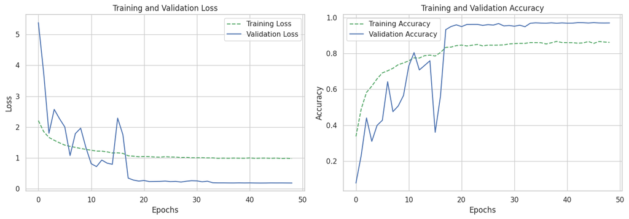

```python
history_df = pd.DataFrame(history.history)
show_plot = plot_model_history(history_df)
show_plot()
```

#### Evaluation on test set

- This is to check for overfitting
- And also how the model performs with respect to each classes

```python
cls_df_final = evaluation_test(final_model, X_test_small, y_test_small, labels_dict)
cls_df_final
```

```
Accuracy: 0.9723333333333334
```

|  | precision | recall | f1-score | support |
| --- | --- | --- | --- | --- |
| Potato | 0.983784 | 0.910000 | 0.945455 | 200.000000 |
| Tomato | 0.937198 | 0.970000 | 0.953317 | 200.000000 |
| Pumpkin | 0.941748 | 0.970000 | 0.955665 | 200.000000 |
| Cabbage | 0.964467 | 0.950000 | 0.957179 | 200.000000 |
| Brinjal | 0.942308 | 0.980000 | 0.960784 | 200.000000 |
| Bitter_Gourd | 0.979592 | 0.960000 | 0.969697 | 200.000000 |
| Cauliflower | 0.974747 | 0.965000 | 0.969849 | 200.000000 |
| Radish | 0.989637 | 0.955000 | 0.972010 | 200.000000 |
| weighted avg | 0.972730 | 0.972333 | 0.972299 | 3000.000000 |
| macro avg | 0.972730 | 0.972333 | 0.972299 | 3000.000000 |
| accuracy | 0.972333 | 0.972333 | 0.972333 | 0.972333 |
| Cucumber | 0.952381 | 1.000000 | 0.975610 | 200.000000 |
| Carrot | 0.984772 | 0.970000 | 0.977330 | 200.000000 |
| Bean | 0.975124 | 0.980000 | 0.977556 | 200.000000 |
| Broccoli | 0.989950 | 0.985000 | 0.987469 | 200.000000 |
| Papaya | 0.985149 | 0.995000 | 0.990050 | 200.000000 |
| Capsicum | 0.990099 | 1.000000 | 0.995025 | 200.000000 |
| Bottle_Gourd | 1.000000 | 0.995000 | 0.997494 | 200.000000 |

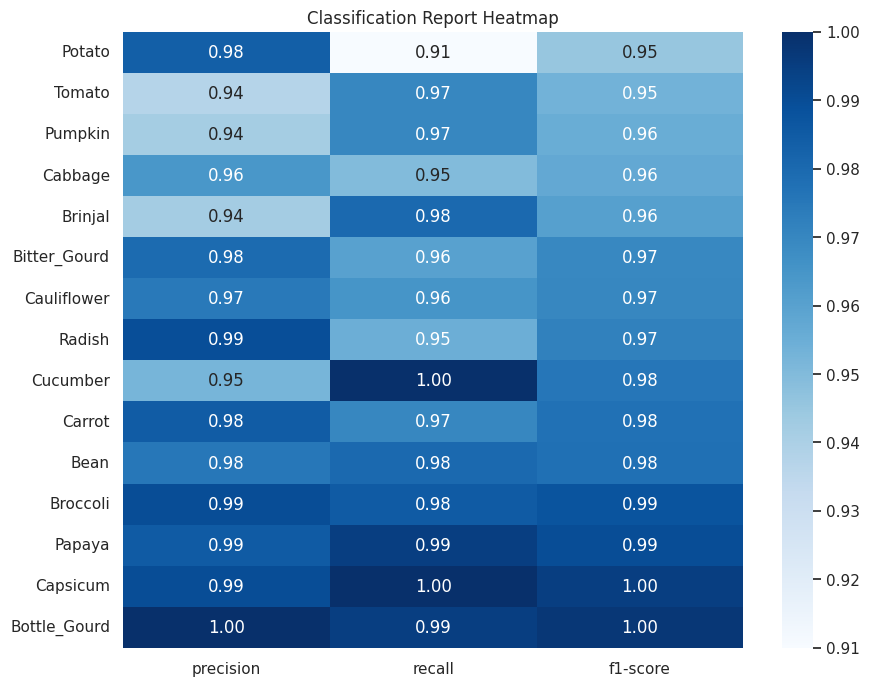

```python
plot_classification_heatmap(cls_df_final)
```

*Things Observed*

#### Cohen Kappa Coefficient

```python
y_pred = final_model.predict(X_test_small)
y_pred_classes = np.argmax(y_pred, axis=1)
kappa_final = cohen_kappa_score(y_test_small, y_pred_classes)
print("Cohen’s Kappa Score:", kappa_final)
```

```
Cohen’s Kappa Score: 0.9703571428571428
```

*Things Observed*

- From the Cophen Kappa Coefficient, we can see that the model is reliable at 97

#### Save the model weights

```python
final_model.save('best_small_image_model.h5')
```

## __Final 128 x 128 Model__

Here is to set the final 128 x 128 model

```python
train_ds_one = tf.data.Dataset.from_tensor_slices((X_train_big, y_train_big)).shuffle(2048).map(preprocess_data, num_parallel_calls=tf.data.AUTOTUNE)
train_ds_two = tf.data.Dataset.from_tensor_slices((X_train_big, y_train_big)).shuffle(2048).map(preprocess_data, num_parallel_calls=tf.data.AUTOTUNE)

val_ds_cutmix = tf.data.Dataset.from_tensor_slices((X_val_big, y_val_big))
val_ds_cutmix = val_ds_cutmix.map(preprocess_data, num_parallel_calls=tf.data.AUTOTUNE).batch(128).prefetch(tf.data.AUTOTUNE)

train_ds_cutmix = tf.data.Dataset.zip((train_ds_one, train_ds_two))
train_ds_cutmix = (
    train_ds_cutmix.shuffle(1024)
    .map(cutmix2, num_parallel_calls=tf.data.AUTOTUNE)
    .batch(128)
    .prefetch(tf.data.AUTOTUNE)
)
train_ds_cutmix
```

```
<PrefetchDataset element_spec=(TensorSpec(shape=(None, 128, 128, 1), dtype=tf.float32, name=None), TensorSpec(shape=(None, 15), dtype=tf.float32, name=None))>
```

### CNN 2 with Cutmix

```python
def CNN2_128(name='Final_Model'):

    filters_list = [32, 64, 128, 128, 128, 128]

    model = Sequential()

    # Add initial convolutional layers
    model.add(Conv2D(filters=filters_list[0], kernel_size=(3, 3), padding='same', input_shape=(128, 128, 1)))
    model.add(BatchNormalization())
    model.add(ReLU())

    model.add(Conv2D(filters=filters_list[1], kernel_size=(3, 3), padding='same'))
    model.add(BatchNormalization())
    model.add(ReLU())

    for filters in filters_list[2:]:
        model.add(Conv2D(filters=filters, kernel_size=(3, 3), padding='same'))
        model.add(BatchNormalization())
        model.add(ReLU())

    model.add(GlobalAveragePooling2D())
    model.add(Dense(256, activation='relu'))
    model.add(Dense(15, activation='softmax'))

    model.compile(optimizer='adam', loss='categorical_crossentropy', metrics=['accuracy'])
    model.summary()
    return model
```

```python
final_model2 = CNN2_128()
```

```
Model: "sequential_8"
_________________________________________________________________
 Layer (type)                Output Shape              Param #
=================================================================
 conv2d_45 (Conv2D)          (None, 128, 128, 32)      320

 batch_normalization_45 (Bat  (None, 128, 128, 32)     128
 chNormalization)

 re_lu_45 (ReLU)             (None, 128, 128, 32)      0

 conv2d_46 (Conv2D)          (None, 128, 128, 64)      18496

 batch_normalization_46 (Bat  (None, 128, 128, 64)     256
 chNormalization)

 re_lu_46 (ReLU)             (None, 128, 128, 64)      0

 conv2d_47 (Conv2D)          (None, 128, 128, 128)     73856

 batch_normalization_47 (Bat  (None, 128, 128, 128)    512
 chNormalization)

 re_lu_47 (ReLU)             (None, 128, 128, 128)     0

 conv2d_48 (Conv2D)          (None, 128, 128, 128)     147584

 batch_normalization_48 (Bat  (None, 128, 128, 128)    512
 chNormalization)

 re_lu_48 (ReLU)             (None, 128, 128, 128)     0

 conv2d_49 (Conv2D)          (None, 128, 128, 128)     147584

 batch_normalization_49 (Bat  (None, 128, 128, 128)    512
 chNormalization)

 re_lu_49 (ReLU)             (None, 128, 128, 128)     0

 conv2d_50 (Conv2D)          (None, 128, 128, 128)     147584

 batch_normalization_50 (Bat  (None, 128, 128, 128)    512
 chNormalization)

 re_lu_50 (ReLU)             (None, 128, 128, 128)     0

 global_average_pooling2d_8   (None, 128)              0
 (GlobalAveragePooling2D)

 dense_16 (Dense)            (None, 256)               33024

 dense_17 (Dense)            (None, 15)                3855

=================================================================
Total params: 574,735
Trainable params: 573,519
Non-trainable params: 1,216
_________________________________________________________________
```

```python
history2 = final_model2.fit(train_ds_cutmix, validation_data = val_ds_cutmix, epochs=100,callbacks=[EarlyStopping(monitor='accuracy', patience=10, restore_best_weights=True), ReduceLROnPlateau(patience=5)])
```

#### Plot the graph

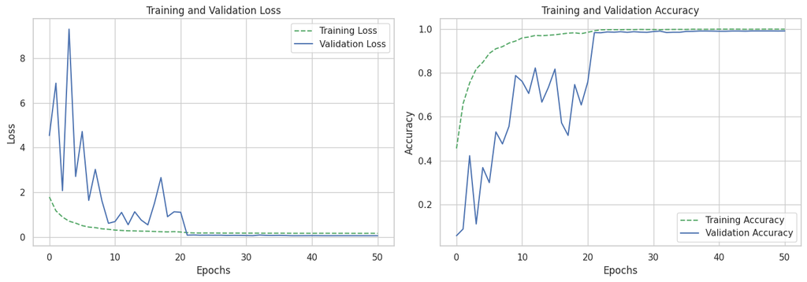

```python
history_df = pd.DataFrame(history2.history)
show_plot = plot_model_history(history_df)
show_plot()
```

#### Evaluation on test set

- This is to check for overfitting
- And also how the model performs with respect to each classes

```python
cls_df_final = evaluation_test(final_model2, X_test_big, y_test_big, labels_dict)
cls_df_final
```

```
Accuracy: 0.9883333333333333
```

|  | precision | recall | f1-score | support |
| --- | --- | --- | --- | --- |
| Radish | 0.994764 | 0.950000 | 0.971867 | 200.000000 |
| Pumpkin | 0.980100 | 0.985000 | 0.982544 | 200.000000 |
| Bitter_Gourd | 0.975369 | 0.990000 | 0.982630 | 200.000000 |
| Cauliflower | 0.985000 | 0.985000 | 0.985000 | 200.000000 |
| Capsicum | 0.980198 | 0.990000 | 0.985075 | 200.000000 |
| Carrot | 0.975490 | 0.995000 | 0.985149 | 200.000000 |
| Potato | 0.989950 | 0.985000 | 0.987469 | 200.000000 |
| Bean | 0.985075 | 0.990000 | 0.987531 | 200.000000 |
| macro avg | 0.988422 | 0.988333 | 0.988320 | 3000.000000 |
| weighted avg | 0.988422 | 0.988333 | 0.988320 | 3000.000000 |
| accuracy | 0.988333 | 0.988333 | 0.988333 | 0.988333 |
| Cabbage | 0.994949 | 0.985000 | 0.989950 | 200.000000 |
| Tomato | 0.980392 | 1.000000 | 0.990099 | 200.000000 |
| Brinjal | 0.990050 | 0.995000 | 0.992519 | 200.000000 |
| Broccoli | 1.000000 | 0.990000 | 0.994975 | 200.000000 |
| Cucumber | 0.995000 | 0.995000 | 0.995000 | 200.000000 |
| Papaya | 1.000000 | 0.995000 | 0.997494 | 200.000000 |
| Bottle_Gourd | 1.000000 | 0.995000 | 0.997494 | 200.000000 |

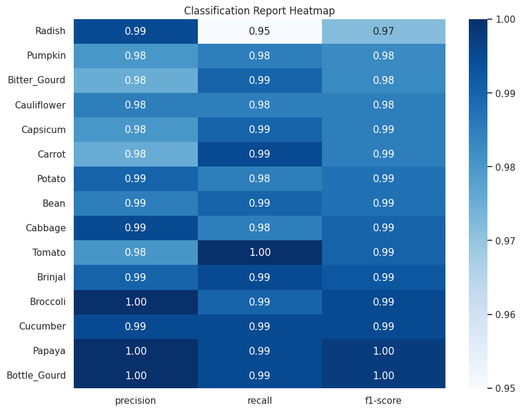

```python
plot_classification_heatmap(cls_df_final)
```

*Things Observed*

- From the heatmap and the evaluation score, we can see that the model is at 98,8%, similar to train accuracy hence no overfitting  
- In addition, the model is best at prediction Bottle Gourd and worst at Radish in terms of f1 score

#### Cohan Kappa Coefficient

```python
y_pred = final_model2.predict(X_test_big)
y_pred_classes = np.argmax(y_pred, axis=1)
kappa_final = cohen_kappa_score(y_test_big, y_pred_classes)
print("Cohen’s Kappa Score:", kappa_final)
```

```
Cohen’s Kappa Score: 0.9875
```

*Things Observed*

- From the Cophen Kappa Coefficient, we can see that the model is reliable at 98.75

```python
final_model2.save('best_large_image_model.h5')
```